# 308.2. Solar System object observations

For the Rubin Science Platform at data.lsst.cloud.  
Data Release: [Data Preview 2](https://dp2.lsst.io/)  
Container Size: Large  
LSST Science Pipelines version: r30.0.9  
Last verified to run: 2026-07-20  
Repository: github.com/lsst/tutorial-notebooks  
DOI: 10.11578/rubin/dc.20250909.20

**Learning objective:** An overview of the Data Preview 2 (DP2) Solar System object observations.

**LSST data products:** `SSSource`, `SSObject`

**Packages:** `lsst.rsp`, `lsst.daf.butler`, `lsst.utils.plotting`

**Credit:** Originally developed by the Rubin Community Science team. Please consider acknowledging them if this notebook is used for the preparation of journal articles, software releases, or other notebooks.

**Get Support:** Everyone is encouraged to ask questions or raise issues in the [Support Category](https://community.lsst.org/c/support) of the Rubin Community Forum. Rubin staff will respond to all questions posted there.

## 1. Introduction

This notebook examines the 8,136,150 observations of the 299,343 Solar System objects detected by Rubin in the DP2 data release.

Related tutorials: The 100-level tutorials demonstrate how to use the TAP service. The 200-level tutorials introduce the types of catalog data.

### 1.1. Import packages

Import `numpy`, a fundamental package for scientific computing with arrays in Python (numpy.org), and `matplotlib`, a comprehensive library for data visualization ([matplotlib.org](https://matplotlib.org/); [matplotlib gallery](https://matplotlib.org/stable/gallery/index.html)).

From the `lsst` package, import modules for accessing the Table Access Protocol (TAP) service, and for retrieving datasets from the butler from the LSST Science Pipelines ([pipelines.lsst.io](https://pipelines.lsst.io/)). Additional modules support standardized multiband plotting (`lsst.utils.plotting`) for LSST data analysis and visualization.

```python
import numpy as np
import matplotlib.pyplot as plt
import matplotlib.ticker as ticker

from lsst.rsp import RSPDiscovery
from lsst.daf.butler import Butler
from lsst.utils.plotting import (get_multiband_plot_colors,
                                 get_multiband_plot_symbols)
```

### 1.2. Define parameters and functions

Create an instance of the TAP service.

```python
discovery = RSPDiscovery("dp2")
service = discovery.get_tap_client()
```

Create an instance of the Rubin data butler.

```python
butler = Butler("dp2", collections="dp2")
```

Define parameters to use colorblind-friendly colors with `matplotlib`.

```python
plt.style.use('seaborn-v0_8-colorblind')
prop_cycle = plt.rcParams['axes.prop_cycle']
colors = prop_cycle.by_key()['color']
```

Define the colors and symbols to represent the LSST filters in plots.

```python
filter_colors = get_multiband_plot_colors()
filter_names = filter_colors.keys()
filter_symbols = get_multiband_plot_symbols()
```

## 2. Sky coverage

Query the `SSSource` table to retrieve the on-sky coordinates for all Solar System sources in DP2. The query may take several minutes to complete.

```python
query = "SELECT ssObjectId, "\
        "eclLambda, eclBeta, "\
        "ephRa, ephDec "\
        "FROM dp2.SSSource " \
        "ORDER BY ssObjectId ASC "
job = service.submit_job(query)
job.run()
job.wait(phases=['COMPLETED', 'ERROR'])
print('Job phase is', job.phase)
if job.phase == 'ERROR':
    job.raise_if_error()
```

```
Job phase is COMPLETED
```

Fetch the results as an `astropy` table. There are 8,136,150 Solar System source measurements (detections) in DP2.

```python
assert job.phase == 'COMPLETED'
results = job.fetch_result().to_table()
print(len(results))
```

```
8136150
```

Option to print the results.

```python
# results
```

Plot the sky coverage in ecliptic and equatorial coordinates for all DP2 Solar System sources.

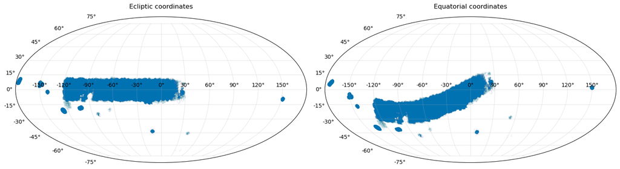

```python
fig, axes = plt.subplots(1, 2, figsize=(16, 5),
                         subplot_kw={'projection': 'mollweide'})

ax = axes[0]
lam = np.deg2rad(results['eclLambda'])
lam = (lam + np.pi) % (2 * np.pi) - np.pi
bet = np.deg2rad(results['eclBeta'])
ax.scatter(lam, bet, s=0.02, alpha=0.03,
           rasterized=True)
ax.set_title('Ecliptic coordinates', pad=15)
ax.grid(True, alpha=0.3)

ax = axes[1]
ra = np.deg2rad(results['ephRa'])
ra = (ra + np.pi) % (2 * np.pi) - np.pi
dec = np.deg2rad(results['ephDec'])
ax.scatter(ra, dec, s=0.02, alpha=0.03,
           rasterized=True)
ax.set_title('Equatorial coordinates', pad=15)
ax.grid(True, alpha=0.3)

plt.tight_layout()
plt.show()
```

## 3. Observations per object

### 3.1. Multiple detections

Find the SS objects with more than one SS source detected in the `SSSource` table. The vast majority (281,856) of the 299,343 DP2 Solar System objects have more than one detection. 17,487 DP2 Solar System objects have a single detection.

```python
values, counts = np.unique(results['ssObjectId'], return_counts=True)
tx = np.where(counts > 1)[0]
print('Solar System objects with >1 detection: ', len(tx))
```

```
Solar System objects with >1 detection:  281856
```

Plot a histogram of the number of sources for each object with more than one detection.

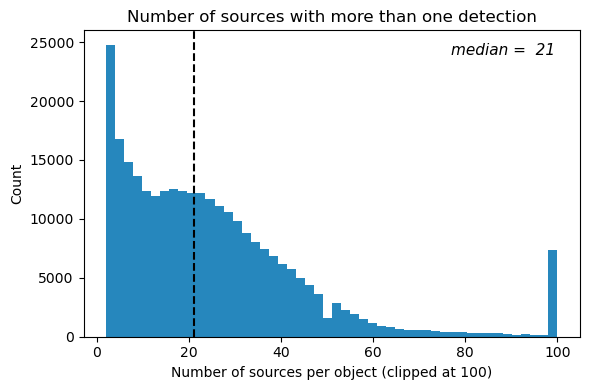

```python
fig, ax = plt.subplots(figsize=(6, 4))

ax.hist(counts[tx].clip(0, 100), bins=50,
        edgecolor='none', alpha=0.85)
plt.xlabel('Number of sources per object (clipped at 100)')
plt.ylabel('Count')
plt.title('Number of sources with more than one detection')
ax.axvline(np.median(counts[tx]), color='black', linestyle='--', lw=1.5)
ax.text(0.95, 0.92,
        f'median = {np.median(counts[tx]): .0f}',
        transform=ax.transAxes, ha='right', fontsize=11,
        fontstyle='italic')

plt.tight_layout()
plt.show()
```

> **Figure 2:** Histogram of the number of source detections for every Solar System object with more than one detection.

Clean up.

```python
job.delete()
del query, results, values, counts, tx
```